# Module_7_Assignment

## Module 7. Perform PCA for Dimensions 6-10 of Chile's Tourism Regions

### Import useful libraries

```python
import pandas as pd
import numpy as np
import matplotlib.pyplot as plt
import seaborn as sns
from sklearn.decomposition import PCA
from sklearn.impute import SimpleImputer
from sklearn.preprocessing import StandardScaler
```

### Data importing

```python
# Set additional parameters for charts and tables

# Remove column display limits
pd.set_option('display.max_columns', None)
# pd.set_option('display.height', None)
pd.set_option('display.max_rows', None)
# pd.set_option('display.width', None)
plt.rcParams['figure.figsize'] = [15, 10]
sns.set_style("white")
```

```python
# Read data in csv format, using encoding, and read the third row as column names
chile_data_2 = pd.read_excel('Tourism Chile D6 - D10 (3_updated1019).xls', encoding = 'ISO-8859-1', header = 5)
```

```python
# Print
chile_data_2.head()
```

|  | Regions | Density of restaurants per 100,000 habitants | People working at restaurants per 10,000 habitants | Car rental agencies | Hospital beds per 10,000 habitants | Density of ATM machines per 100,000 habitants | Spas | Casinos per 100,000 habitants | Golf courses | Artwork Centers | Density of tourist guides per 100,000 habitants | Thermal centers | Density of sports centers per 10,000 habitants | Ski resorts | Major shopping centers | Phone service penetration pero 1,000 habitants | Density of service stations | Number of certified tourism-operators | Number of vineyards | Percentage of crime perception | Percentage of homes with at least one crime victim per year | Density of murders per one million habitants | Density of public health complaints per one million habitants | Crime index | Allocated budget for public safety (millions of chilean pesos) | Porcentage of homes that reported at least one crime | Number of reported crimes | Number of crimes investigated and resolved | Number of accidents (roads; air; water) | … |
| --- | --- | --- | --- | --- | --- | --- | --- | --- | --- | --- | --- | --- | --- | --- | --- | --- | --- | --- | --- | --- | --- | --- | --- | --- | --- | --- | --- | --- | --- | --- |
| 0 | Arica y Parinacota | 35.8567 | 19.563 | 12 | 21.6195 | 43.7662 | NaN | 5.27304 | 1 | 20 | 20.0375 | 5 | NaN | NaN | NaN | 240.55 | 17 | 6 | NaN | 0.318 | 0.26 | 42.1843 | 15.8191 | 0.513 | 11884613 | 0.426 | 26467 | 2387 | 981 | … |
| 1 | Tarapacá | 25.9469 | 26.6164 | 2 | 18.9579 | 60.2637 | NaN | 4.18498 | 3 | 9 | 22.1804 | 5 | 40.1339 | NaN | 2 | 213.07 | 28 | 0 | NaN | 0.421 | 0.468 | 87.8845 | 0 | 0.516 | 14740693 | 0.398 | 76896 | 1862 | 1105 | … |
| 2 | Antofagasta | 37.2482 | 35.4465 | 22 | 29.9605 | 69.233 | 3 | 4.04871 | 3 | 36 | 20.446 | 2 | 14.292 | NaN | 3 | 259.23 | 39 | 2 | NaN | 0.546 | 0.314 | 109.315 | 0 | 0.381 | 22383612 | 0.495 | 123017 | 4228 | 2324 | … |
| 3 | Atacama | 44.8226 | 26.9329 | 19 | 25.4781 | 56.2248 | 1 | 3.93181 | 1 | 9 | 18.4795 | 3 | 32.4374 | NaN | NaN | 184.01 | 35 | 1 | NaN | 0.39 | 0.197 | 66.8407 | 0 | 0.488 | 17068077 | 0.533 | 21705 | 3125 | 965 | … |
| 4 | Coquimbo | 37.632 | 25.1654 | 9 | 17.8047 | 47.7446 | 3 | 3.31559 | 3 | 13 | 6.96275 | 3 | 14.0913 | NaN | 1 | 150.06 | 72 | 3 | NaN | 0.288 | 0.218 | 155.833 | 0 | 0.396 | 20225710 | 0.449 | 69974 | 4203 | 1831 | … |

```python
chile_data_2.tail()
```

|  | Regions | Density of restaurants per 100,000 habitants | People working at restaurants per 10,000 habitants | Car rental agencies | Hospital beds per 10,000 habitants | Density of ATM machines per 100,000 habitants | Spas | Casinos per 100,000 habitants | Golf courses | Artwork Centers | Density of tourist guides per 100,000 habitants | Thermal centers | Density of sports centers per 10,000 habitants | Ski resorts | Major shopping centers | Phone service penetration pero 1,000 habitants | Density of service stations | Number of certified tourism-operators | Number of vineyards | Percentage of crime perception | Percentage of homes with at least one crime victim per year | Density of murders per one million habitants | Density of public health complaints per one million habitants | Crime index | Allocated budget for public safety (millions of chilean pesos) | Porcentage of homes that reported at least one crime | Number of reported crimes | Number of crimes investigated and resolved | Number of accidents (roads; air; water) | … |
| --- | --- | --- | --- | --- | --- | --- | --- | --- | --- | --- | --- | --- | --- | --- | --- | --- | --- | --- | --- | --- | --- | --- | --- | --- | --- | --- | --- | --- | --- | --- |
| 14 | Magallanes y Antártica | 59.0084 | 59.3399 | 12 | 34.6757 | 71.6057 | NaN | 13.2603 | 1 | 15 | 137.244 | 0 | 18.3655 | 1 | 2 | 297.25 | 21 | 3 | NaN | 0.283 | 0.18 | 53.0413 | 6.63016 | 0.367 | 20075842 | 0.414 | 8659 | 2527 | 660 | … |
| 15 | AÑO | 2010 | 2006 | 2011 | 2011 | 2010 | 2011 | 2011 | 2011 | 2011 | 2011 | 2010 | 2004 | 2011 | 2011 | 2011 | 2012 | 2012 | NaN | 2010 | 2010 | 2010 | 2010 | 2010 | 2010 | 2010 | 2008 | 2010 | 2008 | … |
| 16 | FUENTE | INE - Informe anual de turismo | SERNATUR - Turismo y empleo en Chile | SERNATUR - Unidad de servicios turísticos | INE -“Estadísticas de salud” – “Dotación de ca... | SBIF -"Información financiera” – Categoría “Pr... | Atractivos Turísticos Base SIG SERNATUR | Superintendencia de Casinos de Juego – Estadís... | Federación chilena de golf – Listado de clubes | SERNATUR - Unidad de servicios turísticos | SERNATUR - Unidad de servicios turísticos | SERNATUR- Micrositio de rutas termales | INE-Primer Catastro Nacional de Instalaciones ... | SERNATUR - Sitio web Chile es Tuyo | Camara Chilena de Centros Comerciales - Catást... | Subsecretaría de Telecomunicaciones - Series L... | Comisión Nacional de Energía - Sistema de Info... | SERNATUR - Servicio de Angencias de Viajes y T... | SIG Sernatur/ Categoría Realizaciones Técticas... | Subsecretaría de prevención del delito – encue... | INE - Encuesta de seguridad ciudadana | INE – Anuario de Investigaciones | INE – Anuario de Investigaciones | Fundación Paz Ciudadana - Conceptos Nº 22: La ... | DIPRES – instituciones – Ministerio del interi... | INE - Encuesta de seguridad ciudadana | Subsecretaría de prevención del delito | INE – Anuario de Investigaciones | INE - Carabineros Informe Anual 2008 | … |
| 17 | LINK | http://www.ine.cl/canales/menu/publicaciones/c... | http://www.sernatur.cl/estudios-y-estadisticas... | ---------------- | http://www.ine.cl/canales/menu/publicaciones/c... | http://www.sbif.cl/sbifweb/servlet/InfoFinanci... | ---------------- | http://www.scj.cl/estadisticas/analisis_estadi... | http://www.chilegolf.cl/es/clubes | ---------------- | ---------------- | http://www.sernatur.cl/images/lang1/nacional/m... | http://www.ine.cl/canales/sala_prensa/archivo_... | http://www.chileestuyo.cl/historias-y-novedade... | http://www.camaracentroscomerciales.cl/catastr... | http://www.subtel.gob.cl/prontus_subtel/site/a... | http://www.bencinaenlinea.cl/web2/buscador.php... | www.calidadturistica.cl | ---------------- | http://www.seguridadpublica.gov.cl/enusc_2010.... | http://www.ine.cl/canales/chile_estadistico/en... | http://www.ine.cl/canales/chile_estadistico/es... | http://www.ine.cl/canales/chile_estadistico/es... | http://www.pazciudadana.cl/publs.php?&view=A | http://www.dipres.gob.cl/574/multipropertyvalu... | http://www.ine.cl/canales/chile_estadistico/en... | http://www.seguridadpublica.gov.cl/publicacion... | http://www.ine.cl/canales/chile_estadistico/es... | ---------------- | … |
| 18 | Ubicación Archivo base en carpeta interna | Dropbox\D6 SERVICIOS COMPLEMENTARIOS AL TURISM... | Dropbox\D6 SERVICIOS COMPLEMENTARIOS AL TURISM... | Dropbox\D6 SERVICIOS COMPLEMENTARIOS AL TURISM... | Dropbox\D6 SERVICIOS COMPLEMENTARIOS AL TURISM... | Dropbox\D6 SERVICIOS COMPLEMENTARIOS AL TURISM... | Dropbox\D6 SERVICIOS COMPLEMENTARIOS AL TURISM... | Dropbox\D6 SERVICIOS COMPLEMENTARIOS AL TURISM... | Dropbox\D6 SERVICIOS COMPLEMENTARIOS AL TURISM... | Dropbox\D6 SERVICIOS COMPLEMENTARIOS AL TURISM... | Dropbox\D6 SERVICIOS COMPLEMENTARIOS AL TURISM... | Dropbox\D6 SERVICIOS COMPLEMENTARIOS AL TURISM... | Dropbox\D6 SERVICIOS COMPLEMENTARIOS AL TURISM... | Dropbox\ICT Desarrollo\Variables Propuestas\D6... | Dropbox\ICT Desarrollo\Variables Propuestas\D6... | Dropbox\ICT Desarrollo\Variables Propuestas\D6... | Dropbox\ICT Desarrollo\Variables Propuestas\D6... | Dropbox\ICT Desarrollo\Variables Propuestas\D6... | ICT Desarrollo\SIG Sernatur\Atractivos Turísti... | Dropbox\D7 SEGURIDAD PÚBLICA Y PROTECCIÓN AL C... | Dropbox\ICT Desarrollo\D7 SEGURIDAD PÚBLICA Y ... | Dropbox\D7 SEGURIDAD PÚBLICA Y PROTECCIÓN AL C... | Dropbox\D7 SEGURIDAD PÚBLICA Y PROTECCIÓN AL C... | Dropbox\D7 SEGURIDAD PÚBLICA Y PROTECCIÓN AL C... | Dropbox\ICT Desarrollo\D7 SEGURIDAD PÚBLICA Y ... | Dropbox\D7 SEGURIDAD PÚBLICA Y PROTECCIÓN AL C... | Dropbox\D7 SEGURIDAD PÚBLICA Y PROTECCIÓN AL C... | Dropbox\D7 SEGURIDAD PÚBLICA Y PROTECCIÓN AL C... | Dropbox\ICT Desarrollo\Variables Propuestas\D7... | … |

```python
# Remove last rows - from 16 to 18
chile_data_2 = chile_data_2[:-4]
```

### Data Cleaning or renaming

```python
# Rename the first column
chile_data_2 = chile_data_2.rename(columns={'VARIABLE': 'Region'})
```

```python
# Remove $ symbol
chile_data_2 = chile_data_2.replace(r'[<$]', '', regex = True)
# Remove commas from numbers
chile_data_2 = chile_data_2.replace(',','', regex = True)
# Remove `-` character
chile_data_2 = chile_data_2.replace('-','', regex = True)
# Replace empty values with NaNs
chile_data_2 = chile_data_2.replace(r'^\s*$', np.nan, regex = True)
# Check NaNs in the dataset again
chile_data_2
```

|  | Regions | Density of restaurants per 100,000 habitants | People working at restaurants per 10,000 habitants | Car rental agencies | Hospital beds per 10,000 habitants | Density of ATM machines per 100,000 habitants | Spas | Casinos per 100,000 habitants | Golf courses | Artwork Centers | Density of tourist guides per 100,000 habitants | Thermal centers | Density of sports centers per 10,000 habitants | Ski resorts | Major shopping centers | Phone service penetration pero 1,000 habitants | Density of service stations | Number of certified tourism-operators | Number of vineyards | Percentage of crime perception | Percentage of homes with at least one crime victim per year | Density of murders per one million habitants | Density of public health complaints per one million habitants | Crime index | Allocated budget for public safety (millions of chilean pesos) | Porcentage of homes that reported at least one crime | Number of reported crimes | Number of crimes investigated and resolved | Number of accidents (roads; air; water) | … |
| --- | --- | --- | --- | --- | --- | --- | --- | --- | --- | --- | --- | --- | --- | --- | --- | --- | --- | --- | --- | --- | --- | --- | --- | --- | --- | --- | --- | --- | --- | --- |
| 0 | Arica y Parinacota | 35.856658 | 19.562971 | 12 | 21.619455 | 43.766215 | NaN | 5.273038 | 1 | 20 | 20.037544 | 5 | NaN | NaN | NaN | 240.55 | 17 | 6 | NaN | 0.318 | 0.260 | 42.184303 | 15.819114 | 0.513 | 11884613 | 0.426 | 26467 | 2387 | 981 | … |
| 1 | Tarapacá | 25.946851 | 26.616447 | 2 | 18.957941 | 60.263653 | NaN | 4.184976 | 3 | 9 | 22.180372 | 5 | 40.133919 | NaN | 2.0 | 213.07 | 28 | 0 | NaN | 0.421 | 0.468 | 87.884495 | 0.000000 | 0.516 | 14740693 | 0.398 | 76896 | 1862 | 1105 | … |
| 2 | Antofagasta | 37.248170 | 35.446492 | 22 | 29.960485 | 69.233012 | 3.0 | 4.048714 | 3 | 36 | 20.446006 | 2 | 14.291961 | NaN | 3.0 | 259.23 | 39 | 2 | NaN | 0.546 | 0.314 | 109.315281 | 0.000000 | 0.381 | 22383612 | 0.495 | 123017 | 4228 | 2324 | … |
| 3 | Atacama | 44.822597 | 26.932876 | 19 | 25.478108 | 56.224836 | 1.0 | 3.931807 | 1 | 9 | 18.479492 | 3 | 32.437406 | NaN | NaN | 184.01 | 35 | 1 | NaN | 0.390 | 0.197 | 66.840715 | 0.000000 | 0.488 | 17068077 | 0.533 | 21705 | 3125 | 965 | … |
| 4 | Coquimbo | 37.632002 | 25.165365 | 9 | 17.804745 | 47.744567 | 3.0 | 3.315595 | 3 | 13 | 6.962749 | 3 | 14.091278 | NaN | 1.0 | 150.06 | 72 | 3 | NaN | 0.288 | 0.218 | 155.832960 | 0.000000 | 0.396 | 20225710 | 0.449 | 69974 | 4203 | 1831 | … |
| 5 | Valparaíso | 52.407634 | 47.049976 | 16 | 27.755914 | 55.849523 | 9.0 | 1.948239 | 12 | 44 | 12.208966 | 3 | 18.709590 | 2.0 | 8.0 | 230.65 | 179 | 3 | 5.0 | 0.311 | 0.291 | 87.670763 | 1.948239 | 0.432 | 24137492 | 0.445 | 236177 | 19176 | 6765 | … |
| 6 | Metropolitana | 9.222619 | 16.914184 | 47 | 25.508213 | 65.498743 | NaN | NaN | 21 | 42 | 4.834038 | 4 | 14.716594 | 5.0 | 33.0 | 331.61 | 507 | 39 | 1.0 | 0.372 | 0.295 | 65.333759 | 0.659937 | 0.470 | 60400444 | 0.424 | 1146510 | 53517 | 23242 | … |
| 7 | O'Higgins | 18.959119 | 49.421811 | 6 | 19.945505 | 43.426630 | NaN | 2.562043 | 3 | 39 | 9.991968 | 2 | 14.949521 | 1.0 | 2.0 | 117.30 | 114 | 3 | 7.0 | 0.203 | 0.220 | 51.240862 | 0.000000 | 0.396 | 18182163 | 0.477 | 111020 | 4894 | 2451 | … |
| 8 | Maule | 15.637096 | 19.942803 | 10 | 23.852077 | 35.899249 | 9.0 | 1.101204 | 1 | 24 | 8.699511 | 5 | 25.382751 | NaN | 3.0 | 109.73 | 130 | 0 | 2.0 | 0.245 | 0.227 | 27.530099 | 1.101204 | 0.427 | 25936948 | 0.530 | 124820 | 6018 | 4771 | … |
| 9 | Biobío | 14.127921 | 14.004368 | 16 | 27.159987 | 38.193732 | 2.0 | 1.611550 | 6 | 26 | 1.611550 | 3 | 20.531145 | 1.0 | 3.0 | 162.84 | 211 | 1 | NaN | 0.360 | 0.310 | 63.924812 | 0.000000 | 0.420 | 41208340 | 0.410 | 292281 | 19222 | 5713 | … |
| 10 | Araucanía | 15.985555 | 15.686545 | 25 | 25.887400 | 40.826419 | 23.0 | 2.300080 | 2 | 16 | 9.085316 | 13 | 22.736290 | 4.0 | 1.0 | 135.88 | 118 | 5 | NaN | 0.381 | 0.288 | 78.202718 | 1.150040 | 0.369 | 29000528 | 0.469 | 140063 | 8685 | 3161 | … |
| 11 | Los Ríos | 34.512172 | 26.206804 | 9 | 30.471722 | 42.649188 | 2.0 | 2.805868 | 1 | 40 | 8.698190 | 12 | NaN | 1.0 | NaN | 191.32 | 44 | 1 | NaN | 0.274 | 0.270 | 101.011235 | 0.000000 | 0.298 | 15834434 | 0.440 | 22076 | 3235 | 818 | … |
| 12 | Los Lagos | 36.414929 | 27.360029 | 24 | 22.644226 | 47.297552 | 2.0 | 4.185624 | 2 | 27 | 20.928120 | 8 | 25.727636 | 2.0 | 2.0 | 162.58 | 86 | 6 | NaN | 0.323 | 0.201 | 104.640601 | 0.000000 | NaN | 19901362 | 0.426 | 85949 | 8729 | 2023 | … |
| 13 | Aysén | 76.509422 | 40.987190 | 15 | 27.543392 | 43.719669 | NaN | 10.929917 | 0 | 57 | 67.765488 | 4 | 24.264417 | 1.0 | NaN | 170.81 | 20 | 0 | NaN | 0.351 | 0.256 | 174.878678 | 10.929917 | NaN | 15972532 | 0.445 | 14119 | 3349 | 422 | … |
| 14 | Magallanes y Antártica | 59.008394 | 59.339902 | 12 | 34.675719 | 71.605691 | NaN | 13.260313 | 1 | 15 | 137.244242 | 0 | 18.365534 | 1.0 | 2.0 | 297.25 | 21 | 3 | NaN | 0.283 | 0.180 | 53.041253 | 6.630157 | 0.367 | 20075842 | 0.414 | 8659 | 2527 | 660 | … |

### Missing value

In our case we must drop some variables:

- Spas (6 NaNs)
- Major shopping centers (4 NaNs)
- Ski resorts (6 NaNs)
- Number of vineyards (11 NaNs)
- Governmental resources allocated to tourism promotion (5 NaNs) These are variables where 30-70 percent of data is missing. It does not makes sense to impute empty data here plus in general the imputation is a bad idea here, we have only 15 rows here and each missing data point in a row can skew our results.

Then we will start from a simple imputation.

```python
# Drop 5 columns with many NaNs
chile_data_2 = chile_data_2 = chile_data_2.drop(['Spas',
                                                 'Major shopping centers',
                                                 'Ski resorts',
                                                 'Number of vineyards',
                                                 'Governmental resources allocated to tourism promotion ($M)'], axis = 1)
```

```python
# Impute data in  columns
imputer = SimpleImputer(missing_values = np.nan, strategy = 'mean')
chile_data_2[['Casinos per 100,000 habitants',
              'Density of sports centers per 10,000 habitants',
              'Crime index',
              'Illegal commerce',
              'Yearly budget for international tourism promotion ($M)',
              'Seed funds allocated to the tourism sector ($)']] = imputer.fit_transform(chile_data_2[['Casinos per 100,000 habitants',
              'Density of sports centers per 10,000 habitants',
              'Crime index',
              'Illegal commerce',
              'Yearly budget for international tourism promotion ($M)',
              'Seed funds allocated to the tourism sector ($)']])
```

```python
# Setting index
chile_data_2 = chile_data_2.set_index('Regions')

# Select columns
cols = chile_data_2.loc[:, chile_data_2.dtypes == np.object].columns

# Convert to numeric
chile_data_2[cols] = chile_data_2[cols].apply(pd.to_numeric, errors = 'coerce', axis = 1)

# Now all our columns are integers or floats
chile_data_2 = chile_data_2.reset_index()
```

```python
chile_data_2
```

|  | Regions | Density of restaurants per 100,000 habitants | People working at restaurants per 10,000 habitants | Car rental agencies | Hospital beds per 10,000 habitants | Density of ATM machines per 100,000 habitants | Casinos per 100,000 habitants | Golf courses | Artwork Centers | Density of tourist guides per 100,000 habitants | Thermal centers | Density of sports centers per 10,000 habitants | Phone service penetration pero 1,000 habitants | Density of service stations | Number of certified tourism-operators | Percentage of crime perception | Percentage of homes with at least one crime victim per year | Density of murders per one million habitants | Density of public health complaints per one million habitants | Crime index | Allocated budget for public safety (millions of chilean pesos) | Porcentage of homes that reported at least one crime | Number of reported crimes | Number of crimes investigated and resolved | Number of accidents (roads; air; water) | Illegal commerce | Number of police units | Unemployment rate | Poverty rate | … |
| --- | --- | --- | --- | --- | --- | --- | --- | --- | --- | --- | --- | --- | --- | --- | --- | --- | --- | --- | --- | --- | --- | --- | --- | --- | --- | --- | --- | --- | --- | --- |
| 0 | Arica y Parinacota | 35.856658 | 19.562971 | 12 | 21.619455 | 43.766215 | 5.273038 | 1 | 20 | 20.037544 | 5 | 22.026003 | 240.55 | 17 | 6 | 0.318 | 0.260 | 42.184303 | 15.819114 | 0.513 | 11884613 | 0.426 | 26467 | 2387 | 981 | 319.000000 | 265 | 7.3 | 8.2 | … |
| 1 | Tarapacá | 25.946851 | 26.616447 | 2 | 18.957941 | 60.263653 | 4.184976 | 3 | 9 | 22.180372 | 5 | 40.133919 | 213.07 | 28 | 0 | 0.421 | 0.468 | 87.884495 | 0.000000 | 0.516 | 14740693 | 0.398 | 76896 | 1862 | 1105 | 593.000000 | 592 | 4.8 | 13.4 | … |
| 2 | Antofagasta | 37.248170 | 35.446492 | 22 | 29.960485 | 69.233012 | 4.048714 | 3 | 36 | 20.446006 | 2 | 14.291961 | 259.23 | 39 | 2 | 0.546 | 0.314 | 109.315281 | 0.000000 | 0.381 | 22383612 | 0.495 | 123017 | 4228 | 2324 | 7.000000 | 765 | 6.2 | 7.3 | … |
| 3 | Atacama | 44.822597 | 26.932876 | 19 | 25.478108 | 56.224836 | 3.931807 | 1 | 9 | 18.479492 | 3 | 32.437406 | 184.01 | 35 | 1 | 0.390 | 0.197 | 66.840715 | 0.000000 | 0.488 | 17068077 | 0.533 | 21705 | 3125 | 965 | 14.000000 | 504 | 6.4 | 10.2 | … |
| 4 | Coquimbo | 37.632002 | 25.165365 | 9 | 17.804745 | 47.744567 | 3.315595 | 3 | 13 | 6.962749 | 3 | 14.091278 | 150.06 | 72 | 3 | 0.288 | 0.218 | 155.832960 | 0.000000 | 0.396 | 20225710 | 0.449 | 69974 | 4203 | 1831 | 100.000000 | 1082 | 6.0 | 12.3 | … |
| 5 | Valparaíso | 52.407634 | 47.049976 | 16 | 27.755914 | 55.849523 | 1.948239 | 12 | 44 | 12.208966 | 3 | 18.709590 | 230.65 | 179 | 3 | 0.311 | 0.291 | 87.670763 | 1.948239 | 0.432 | 24137492 | 0.445 | 236177 | 19176 | 6765 | 166.000000 | 2761 | 7.5 | 11.6 | … |
| 6 | Metropolitana | 9.222619 | 16.914184 | 47 | 25.508213 | 65.498743 | 4.389926 | 21 | 42 | 4.834038 | 4 | 14.716594 | 331.61 | 507 | 39 | 0.372 | 0.295 | 65.333759 | 0.659937 | 0.470 | 60400444 | 0.424 | 1146510 | 53517 | 23242 | 7605.000000 | 9385 | 7.7 | 8.8 | … |
| 7 | O'Higgins | 18.959119 | 49.421811 | 6 | 19.945505 | 43.426630 | 2.562043 | 3 | 39 | 9.991968 | 2 | 14.949521 | 117.30 | 114 | 3 | 0.203 | 0.220 | 51.240862 | 0.000000 | 0.396 | 18182163 | 0.477 | 111020 | 4894 | 2451 | 762.000000 | 1136 | 6.0 | 9.9 | … |
| 8 | Maule | 15.637096 | 19.942803 | 10 | 23.852077 | 35.899249 | 1.101204 | 1 | 24 | 8.699511 | 5 | 25.382751 | 109.73 | 130 | 0 | 0.245 | 0.227 | 27.530099 | 1.101204 | 0.427 | 25936948 | 0.530 | 124820 | 6018 | 4771 | 194.000000 | 1875 | 6.4 | 15.8 | … |
| 9 | Biobío | 14.127921 | 14.004368 | 16 | 27.159987 | 38.193732 | 1.611550 | 6 | 26 | 1.611550 | 3 | 20.531145 | 162.84 | 211 | 1 | 0.360 | 0.310 | 63.924812 | 0.000000 | 0.420 | 41208340 | 0.410 | 292281 | 19222 | 5713 | 37.000000 | 3193 | 7.9 | 15.8 | … |
| 10 | Araucanía | 15.985555 | 15.686545 | 25 | 25.887400 | 40.826419 | 2.300080 | 2 | 16 | 9.085316 | 13 | 22.736290 | 135.88 | 118 | 5 | 0.381 | 0.288 | 78.202718 | 1.150040 | 0.369 | 29000528 | 0.469 | 140063 | 8685 | 3161 | 323.000000 | 1550 | 8.0 | 18.1 | … |
| 11 | Los Ríos | 34.512172 | 26.206804 | 9 | 30.471722 | 42.649188 | 2.805868 | 1 | 40 | 8.698190 | 12 | 22.026003 | 191.32 | 44 | 1 | 0.274 | 0.270 | 101.011235 | 0.000000 | 0.298 | 15834434 | 0.440 | 22076 | 3235 | 818 | 29.000000 | 773 | 6.4 | 14.3 | … |
| 12 | Los Lagos | 36.414929 | 27.360029 | 24 | 22.644226 | 47.297552 | 4.185624 | 2 | 27 | 20.928120 | 8 | 25.727636 | 162.58 | 86 | 6 | 0.323 | 0.201 | 104.640601 | 0.000000 | 0.421 | 19901362 | 0.426 | 85949 | 8729 | 2023 | 192.000000 | 1409 | 3.5 | 11.8 | … |
| 13 | Aysén | 76.509422 | 40.987190 | 15 | 27.543392 | 43.719669 | 10.929917 | 0 | 57 | 67.765488 | 4 | 24.264417 | 170.81 | 20 | 0 | 0.351 | 0.256 | 174.878678 | 10.929917 | 0.421 | 15972532 | 0.445 | 14119 | 3349 | 422 | 795.461538 | 469 | 4.4 | 5.2 | … |
| 14 | Magallanes y Antártica | 59.008394 | 59.339902 | 12 | 34.675719 | 71.605691 | 13.260313 | 1 | 15 | 137.244242 | 0 | 18.365534 | 297.25 | 21 | 3 | 0.283 | 0.180 | 53.041253 | 6.630157 | 0.367 | 20075842 | 0.414 | 8659 | 2527 | 660 | 795.461538 | 216 | 5.4 | 6.1 | … |

### PCA Analysis

```python
# Finally, we need to standardize data for applying PCA

# Create a copy
chile_data_s_2 = chile_data_2.copy()

# Standardize
scaler = StandardScaler()
chile_data_s_2.loc[:, chile_data_s_2.columns != 'Regions'] = scaler.fit_transform(chile_data_s_2.loc[:, chile_data_s_2.columns != 'Regions'])

# Set region as an index column
chile_data_s_2 = chile_data_s_2.set_index('Regions')
pass
```

```python
# Calculate eigenvalues and vectors
cov_mat          = np.cov(chile_data_s_2.T)
eig_val, eig_vec = np.linalg.eig(cov_mat)
```

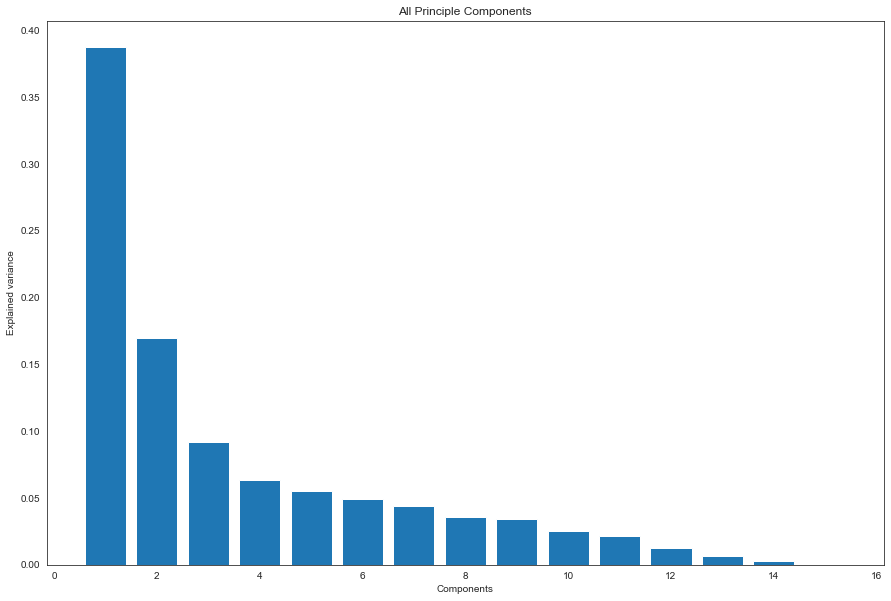

```python
# Run PCA and fit the model
myPCA = PCA()
x = myPCA.fit(chile_data_s_2)

# Plotting the varaince explained by each component
plt.bar(range(1,len(x.explained_variance_ )+1),x.explained_variance_ratio_)
plt.ylabel('Explained variance')
plt.xlabel('Components')
plt.title('All Principle Components')
pass
```

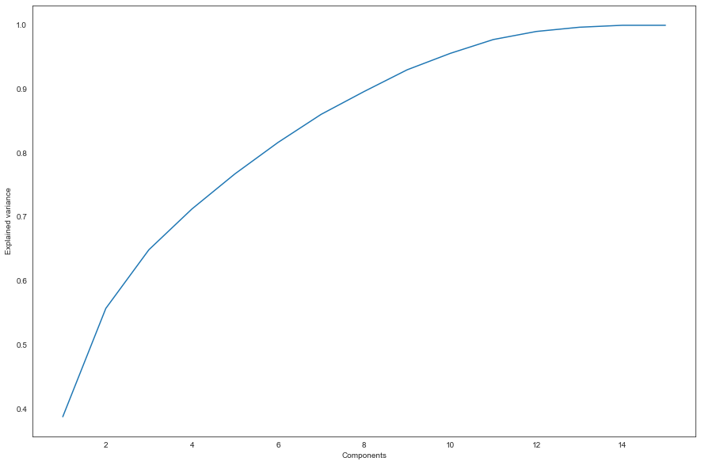

```python
# Deciding on the number of principal componenets to chose
plt.plot(range(1, len(x.explained_variance_)+1), x.explained_variance_ratio_.cumsum())
plt.ylabel('Explained variance')
plt.xlabel('Components')
pass
```

```python
# Calculate the numeric values of principal components
x.explained_variance_ratio_.cumsum()
```

```
array([0.38753711, 0.55706045, 0.64877435, 0.71258677, 0.76757564,
       0.81668524, 0.8605934 , 0.89638569, 0.93035844, 0.95602497,
       0.97768285, 0.99031451, 0.99693677, 1.        , 1.        ])
```

```python
# Calculate loadings
myPCA = PCA(n_components = 7)
pca_model = myPCA.fit(chile_data_s_2)

# Print
print("The loadings are are \n {}".format(pca_model.components_))
```

```
The loadings are are
 [[-1.29774329e-01 -9.29301563e-02  1.98175652e-01 -6.42542798e-03
   6.11573021e-02 -6.82189697e-02  2.21004403e-01  6.10900488e-02
  -9.34189771e-02 -1.71949221e-03 -8.15087010e-02  1.08476898e-01
   2.30092871e-01  2.19880754e-01  4.67817906e-02  4.72176562e-02
  -3.99436756e-02 -7.54520172e-02  4.50473608e-02  2.20364544e-01
  -3.64647082e-02  2.35856803e-01  2.31985639e-01  2.33784878e-01
   2.10637086e-01  2.34347647e-01  1.07418733e-01  1.32913951e-02
  -2.90873829e-02  2.29617703e-01 -2.81825827e-02  2.07435141e-01
   1.91876233e-01  2.26339615e-01  8.35818073e-02 -1.22854957e-01
   1.69172293e-01  2.14126138e-01 -6.30383254e-02 -5.91876237e-02
   2.20733352e-01  1.69982693e-01 -3.74151928e-02  1.93951913e-01
  -3.12718994e-02]
 [ 2.38361843e-01  2.34537403e-01  7.20011096e-02  1.85147016e-01
   2.59945844e-01  3.16666169e-01  4.47846732e-02  1.03672929e-01
   2.86962215e-01 -1.80031849e-01 -6.62470976e-02  2.65144162e-01
  -2.17719743e-02  8.80403076e-02  6.14274739e-02 -5.83739635e-02
   6.24335177e-02  1.75368757e-01  1.55678540e-02 -1.82168373e-02
  -8.72667220e-02  3.58598656e-02  2.88690775e-02  2.83992144e-02
   1.18859045e-01  6.67560421e-03 -1.14195231e-01 -3.25761937e-01
   2.66162174e-02  7.51805279e-02 -5.45699178e-02  7.19635259e-02
   3.26497179e-02  8.93776812e-02  5.05337830e-02  2.84697867e-01
   2.49762877e-02  1.56992350e-02 -5.88499097e-02  3.13261960e-01
  -5.62793062e-02 -6.09955955e-02 -1.45128578e-01 -9.82022084e-02
  -1.92132003e-01]
 [-6.15074232e-02 -1.05764992e-01 -6.83728797e-02 -2.09246738e-01
   1.62645360e-01 -2.69178154e-02  5.40895189e-03 -2.17925081e-01
  -6.31583034e-02 -1.68571678e-02  3.38626237e-01  9.70529994e-02
  -6.61150399e-02  1.01862798e-02  2.35899570e-01  3.40797451e-01
  -3.33000999e-02 -6.60911002e-03  3.40100688e-01 -8.44378630e-02
  -3.47962362e-02  3.02215656e-03 -4.72401796e-02 -1.54061373e-02
   4.16365906e-02 -3.68847462e-02 -5.81969064e-02  4.04276205e-03
   4.16990328e-01  3.29926237e-02  7.47106393e-02  1.84508783e-01
  -9.47845036e-03  1.27188308e-02  7.00542784e-02 -1.48358338e-02
   1.21907789e-01 -2.38881631e-02 -2.82999755e-01 -9.05913751e-02
  -8.56363222e-02 -1.60583489e-01 -2.10782836e-01 -1.47495436e-01
   1.01269675e-02]
 [-1.35988059e-02  4.22003376e-02  9.31368970e-02  1.59642798e-01
   2.22773948e-01 -1.23753011e-01 -4.78854824e-02 -4.63777656e-02
  -8.46830525e-02 -5.34964574e-02 -1.60997305e-01  4.74259375e-02
```

[output cut: 30 more lines]

```
   1.01383285e-01  8.36222764e-02 -8.18743762e-02  1.76273859e-01
  -1.64963043e-03  1.44753079e-01 -1.36211758e-01 -3.72997049e-02
   2.55834917e-01]
 [-1.62554865e-01  1.46067709e-02 -8.25616343e-02  2.77561387e-01
   1.87603489e-01  3.50688405e-02  3.90479540e-02 -3.27049605e-01
   1.93051132e-01 -1.41993924e-01 -5.41642146e-03  2.21260060e-01
   2.89010428e-02 -7.01386917e-02  6.74122889e-02  1.39075269e-01
  -3.60814659e-01 -6.80709072e-02 -5.25479995e-02  1.48573762e-01
  -2.53126585e-01  8.21034450e-03  2.98989612e-02 -3.20194432e-04
  -7.93924864e-02  7.75877590e-03  2.58108679e-01  1.62377113e-01
   1.57173731e-01 -3.53487813e-02  1.41753470e-01 -1.99487514e-02
  -1.52667799e-01 -4.34511232e-02  4.69521834e-02  5.82691115e-02
  -7.22375693e-02 -6.95827415e-02  3.68225654e-01  2.65599416e-02
   5.15325420e-02 -3.38236998e-02  1.91243901e-01  1.41558051e-01
   2.20944281e-02]]
```